# Mise en oeuvre du panneau lumineux

## Présentation

Le panneau lumineux est un afficheur extérieur à Leds 16x96 (Ambre, pitch 16). Il a été facturé 2550 euros HT par la société DVI SIGNS.

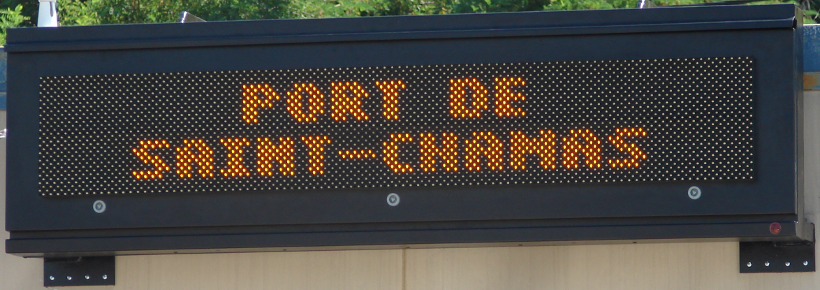

Site : [www.dvisigns.com](http://www.dvisigns.com/)

Documentations : doc/panneau-lumineux/

```
Débrancher l'alimentation.
Ouvrir le panneau et identifier la carte principale (controller board).
Noter l'adresse MAC du module LTRX XPort, information indispensable pour configurer ensuite l'adresse IP de l'afficheur.
Vérifier que la connectivité XPort est activée (switch 1 to ON).
Refermer le panneau.
Brancher le câble Ethernet RJ45.
Rebrancher l'alimentation.
```

## Installation Device Installer

Le panneau lumineux possède une liaison **Ethernet** via un module [LTRX XPort](http://www.lantronix.com/products/xport/) de Lantronix. Ce module réalise un pont RS232-RS485/Ethernet.

*Remarque :* l’adresse MAC du module LTRX XPort du panneau lumineux est `00:20:4A:BA:01:C7`.

Il est nécessaire d’installer l’outil `DeviceInstaller` pour pouvoir configurer les propriétés de communication IP de l’afficheur.

Télécharger sur le site [Lantronix](http://ltxfaq.custhelp.com/app/answers/detail/a_id/644) la dernière version de [DeviceInstaller](http://www.lantronix.com/ftp/DeviceInstaller/Lantronix/4.4/4.4.0.2RC3/Installers/SingleInstallFiles/setup_di_x86x64cd_4.4.0.2RC3.exe).

Suivre la procédure d’installation (*Windows Seven*) :

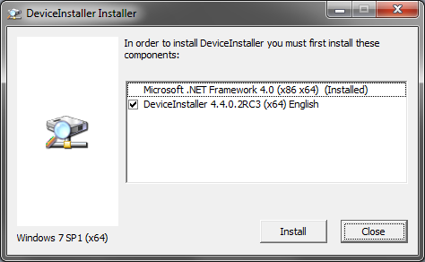

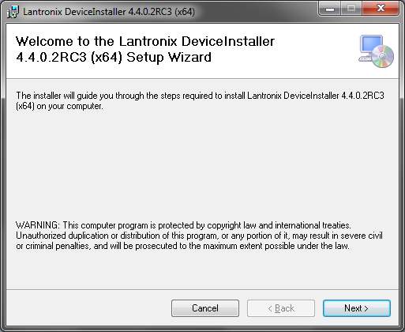

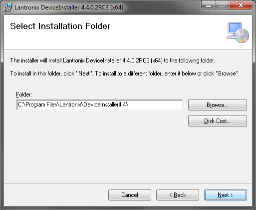

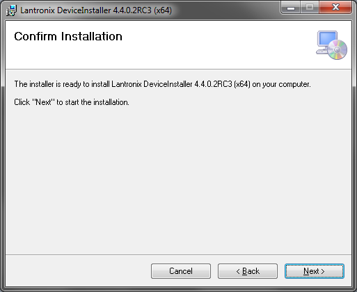

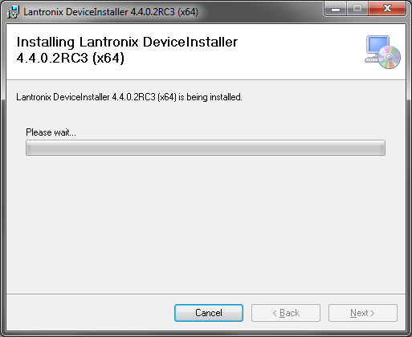

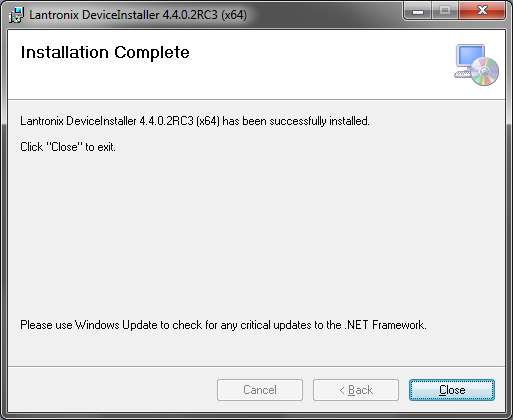

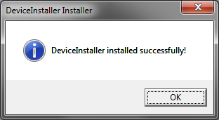

Puis, exécuter `DeviceInstaller.exe` :

[figure not shown]

Ici, le panneau lumineux est détecté (`192.168.52.250`) :

[figure not shown]

## Assigner une adresse IP

En cliquant sur **Assign IP**, il est possible de lui affectuer une adresse IP :

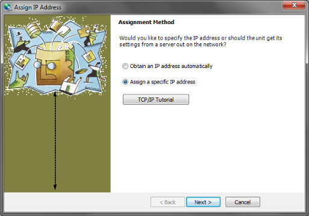

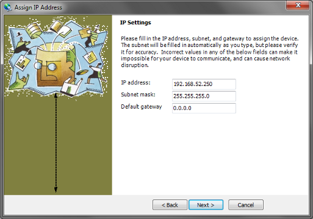

## Installation Multimedia led 2007

Le panneau a été livré avec l’application **Multimedia led 2007**, un logiciel permettant d’exploiter l’afficheur.

Logiciel et manuels : doc/panneau-lumineux/

Installer le logiciel Multimedia 2007 :

[figure not shown]

[figure not shown]

[figure not shown]

[figure not shown]

[figure not shown]

[figure not shown]

Une fois l’installation terminée, lancer le logiciel Multimedia led 2007 :

[figure not shown]

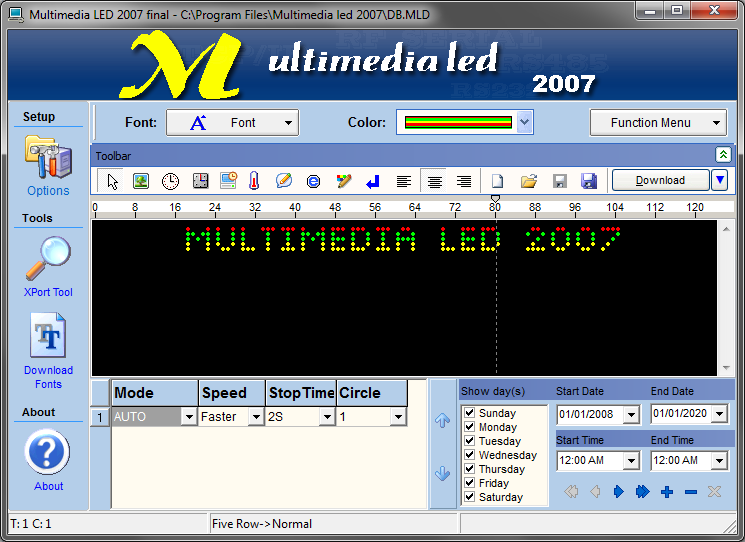

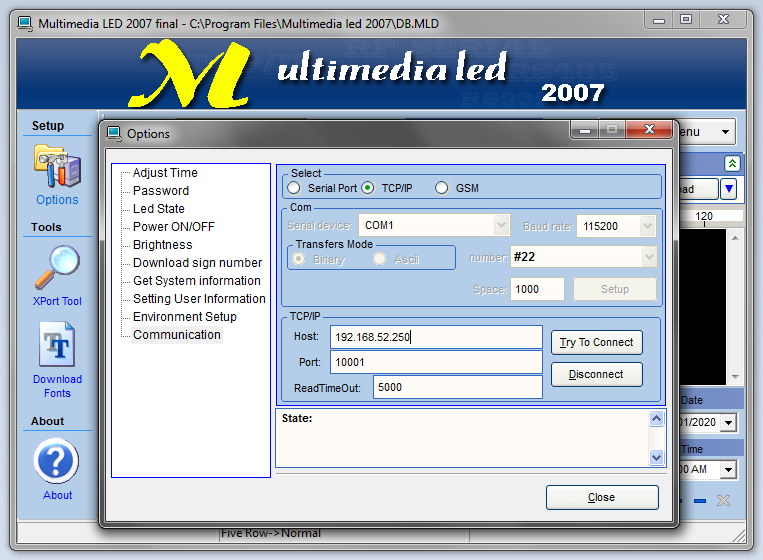

Cliquer sur Try To Connect pour tester la communication avec l’afficheur :

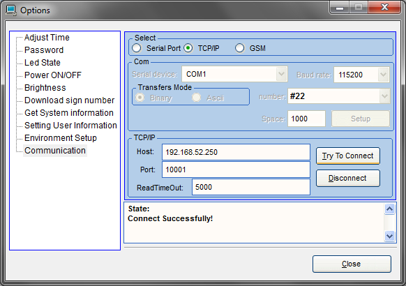

## Utilisation de Multimedia led 2007

Tester en saisissant un message puis cliquer sur Download :

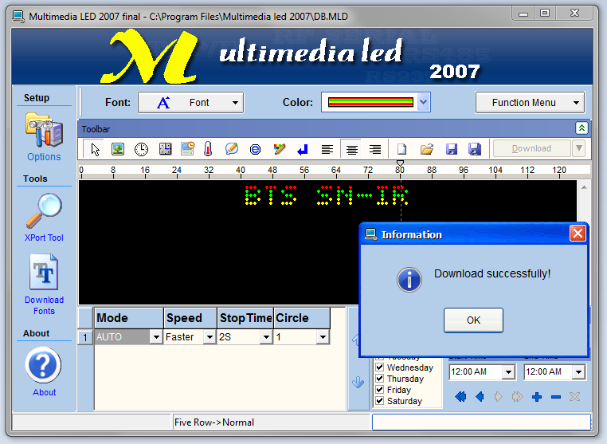

Retour au sommaire